# Building Transactional Frequency Models

In this workbook we investigate different ways to model the transaction frequency of individual customers, with a view to expanding this approach into a more traditional P/NBD model.

# 1 Load and Configure Datasets

We first want to load some synthetic transaction data.

```r
customer_cohort_tbl <- read_rds("data/synthdata_singleyear_cohort_tbl.rds")
customer_cohort_tbl %>% glimpse()
```

```
## Rows: 50,000
## Columns: 4
## $ customer_id    <chr> "8JRWQHAXGE", "8D1JREK9KR", "OXUF71I25Q", "1SCZ4QOQ4Y",…
## $ cohort_qtr     <chr> "2019 Q1", "2019 Q1", "2019 Q1", "2019 Q1", "2019 Q1", …
## $ cohort_ym      <chr> "2019 01", "2019 01", "2019 01", "2019 01", "2019 01", …
## $ first_tnx_date <date> 2019-01-01, 2019-01-01, 2019-01-01, 2019-01-01, 2019-0…
```

```r
customer_simparams_tbl <- read_rds("data/synthdata_singleyear_simparams_tbl.rds")
customer_simparams_tbl %>% glimpse()
```

```
## Rows: 50,000
## Columns: 8
## $ customer_id     <chr> "000JSNK3XH", "001A7TLTYV", "004GMUBSCD", "004LAX8P44"…
## $ cohort_qtr      <chr> "2019 Q1", "2019 Q1", "2019 Q1", "2019 Q1", "2019 Q1",…
## $ cohort_ym       <chr> "2019 01", "2019 01", "2019 01", "2019 01", "2019 01",…
## $ first_tnx_date  <date> 2019-01-01, 2019-01-01, 2019-01-01, 2019-01-01, 2019-…
## $ customer_tau    <dbl> 53, 53, 53, 53, 53, 53, 53, 53, 53, 53, 53, 53, 53, 53…
## $ customer_lambda <dbl> 0.63746283, 0.05247298, 0.06824901, 0.20599461, 1.1217…
## $ customer_nu     <dbl> 0.449753057, 0.456665157, 0.263130590, 0.007679448, 1.…
## $ customer_p      <dbl> 100, 100, 100, 100, 100, 100, 100, 100, 100, 100, 100,…
```

```r
customer_transactions_tbl <- read_rds("data/synthdata_singleyear_transactions_tbl.rds")
customer_transactions_tbl %>% glimpse()
```

```
## Rows: 919,470
## Columns: 5
## $ customer_id   <chr> "000JSNK3XH", "000JSNK3XH", "000JSNK3XH", "000JSNK3XH", …
## $ cohort_qtr    <chr> "2019 Q1", "2019 Q1", "2019 Q1", "2019 Q1", "2019 Q1", "…
## $ cohort_ym     <chr> "2019 01", "2019 01", "2019 01", "2019 01", "2019 01", "…
## $ tnx_timestamp <dttm> 2019-01-01 19:52:38, 2019-01-16 20:04:48, 2019-01-23 23…
## $ tnx_amount    <dbl> 234.83, 213.38, 214.90, 180.31, 234.99, 245.72, 226.07, …
```

## 1.1 Construct Frequency Data

```r
customer_summarystats_tbl <- customer_transactions_tbl %>%
  group_by(customer_id) %>%
  summarise(
    .groups = "drop",

    tnx_count    = n(),
    first_tnx_ts = min(tnx_timestamp),
    last_tnx_ts  = max(tnx_timestamp),
    btyd_count   = tnx_count - 1,
    all_weeks    = 52,
    tnx_weeks    = difftime(last_tnx_ts, first_tnx_ts, units = "weeks") %>% as.numeric(),
    tnx_weeks    = if_else(btyd_count > 0, tnx_weeks, 52),
    obs_freq     = btyd_count / tnx_weeks,
    emp_freq     = btyd_count / all_weeks
    )

customer_summarystats_tbl %>% glimpse()
```

```
## Rows: 50,000
## Columns: 9
## $ customer_id  <chr> "000JSNK3XH", "001A7TLTYV", "004GMUBSCD", "004LAX8P44", "…
## $ tnx_count    <int> 29, 3, 2, 16, 60, 9, 42, 2, 7, 132, 27, 2, 10, 3, 13, 5, …
## $ first_tnx_ts <dttm> 2019-01-01 19:52:38, 2019-01-01 01:53:18, 2019-01-01 18:…
## $ last_tnx_ts  <dttm> 2019-11-19 10:48:17, 2019-12-25 16:49:55, 2019-08-20 05:…
## $ btyd_count   <dbl> 28, 2, 1, 15, 59, 8, 41, 1, 6, 131, 26, 1, 9, 2, 12, 4, 1…
## $ all_weeks    <dbl> 52, 52, 52, 52, 52, 52, 52, 52, 52, 52, 52, 52, 52, 52, 5…
## $ tnx_weeks    <dbl> 45.94600, 51.23181, 32.91996, 50.42715, 51.90082, 45.4073…
## $ obs_freq     <dbl> 0.60941109, 0.03903825, 0.03037671, 0.29745883, 1.1367836…
## $ emp_freq     <dbl> 0.53846154, 0.03846154, 0.01923077, 0.28846154, 1.1346153…
```

We want to view the transactions to get a sense of how regular our transactions are in general.

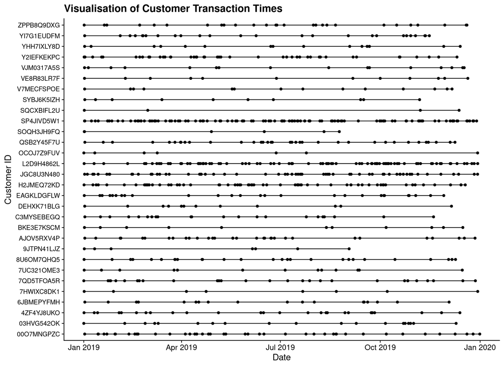

```r
plot_tbl <- customer_transactions_tbl %>%
  group_nest(customer_id, .key = "cust_data") %>%
  filter(map_int(cust_data, nrow) > 3) %>%
  slice_sample(n = 30) %>%
  unnest(cust_data)

ggplot(plot_tbl, aes(x = tnx_timestamp, y = customer_id)) +
  geom_line() +
  geom_point() +
  labs(
    x = "Date",
    y = "Customer ID",
    title = "Visualisation of Customer Transaction Times"
    ) +
  theme(axis.text.y = element_text(size = 10))
```

## 1.2 Construct Data Subsets

For the purposes of saving on time and computation, we construct a subset of the data first, and rather than constructing different samples each time we instead construct sets of `customer_id` to draw upon, then using those list of values when we want to take a subset.

We do this by randomly shuffling the data and then selecting the top $n$ values of `customer_id`.

```r
shuffle_tbl <- customer_summarystats_tbl %>%
  slice_sample(n = nrow(.), replace = FALSE)

id_1000  <- shuffle_tbl %>% head(1000)  %>% pull(customer_id) %>% sort()
id_5000  <- shuffle_tbl %>% head(5000)  %>% pull(customer_id) %>% sort()
id_10000 <- shuffle_tbl %>% head(10000) %>% pull(customer_id) %>% sort()
```

We now have a list of `customer_id` values we use to subset the data.

# 2 Construct Flat Frequency Model

For first frequency model we fit each customer’s transaction frequency independent of the other customers. We start with the estimation that the average customer frequency is about one transaction every four weeks (once a month) so this value determines our initial prior distribution for the transaction frequency.

For our initial fit, we use only 1,000 eligible customers to reduce computation time and construct a dataset used to fit these models.

```r
fit_1000_data_tbl <- customer_summarystats_tbl %>%
  filter(
    customer_id %in% id_1000
    )

fit_1000_data_tbl %>% glimpse()
```

```
## Rows: 1,000
## Columns: 9
## $ customer_id  <chr> "00RC3IE4XG", "02NO5FZ0VS", "02RE0JNCFQ", "04COTHYBKJ", "…
## $ tnx_count    <int> 4, 2, 53, 19, 1, 4, 27, 16, 25, 21, 16, 46, 16, 2, 8, 5, …
## $ first_tnx_ts <dttm> 2019-01-01 08:59:28, 2019-01-01 06:23:37, 2019-01-01 04:…
## $ last_tnx_ts  <dttm> 2019-07-30 12:39:28, 2019-02-18 02:35:37, 2019-12-15 16:…
## $ btyd_count   <dbl> 3, 1, 52, 18, 0, 3, 26, 15, 24, 20, 15, 45, 15, 1, 7, 4, …
## $ all_weeks    <dbl> 52, 52, 52, 52, 52, 52, 52, 52, 52, 52, 52, 52, 52, 52, 5…
## $ tnx_weeks    <dbl> 30.021826, 6.834524, 49.786903, 51.422187, 52.000000, 45.…
## $ obs_freq     <dbl> 0.09992730, 0.14631596, 1.04445139, 0.35004346, 0.0000000…
## $ emp_freq     <dbl> 0.05769231, 0.01923077, 1.00000000, 0.34615385, 0.0000000…
```

We do the same for the 10k customers.

```r
fit_10000_data_tbl <- customer_summarystats_tbl %>%
  filter(
    customer_id %in% id_10000
    )

fit_10000_data_tbl %>% glimpse()
```

```
## Rows: 10,000
## Columns: 9
## $ customer_id  <chr> "000JSNK3XH", "004LAX8P44", "0068WIE4X2", "00O7MNGPZC", "…
## $ tnx_count    <int> 29, 16, 9, 43, 11, 4, 6, 4, 1, 7, 26, 7, 2, 9, 9, 11, 11,…
## $ first_tnx_ts <dttm> 2019-01-01 19:52:38, 2019-01-01 23:38:35, 2019-01-01 12:…
## $ last_tnx_ts  <dttm> 2019-11-19 10:48:17, 2019-12-20 23:24:14, 2019-11-15 09:…
## $ btyd_count   <dbl> 28, 15, 8, 42, 10, 3, 5, 3, 0, 6, 25, 6, 1, 8, 8, 10, 10,…
## $ all_weeks    <dbl> 52, 52, 52, 52, 52, 52, 52, 52, 52, 52, 52, 52, 52, 52, 5…
## $ tnx_weeks    <dbl> 45.945997, 50.427147, 45.407391, 51.975108, 47.378704, 30…
## $ obs_freq     <dbl> 0.60941109, 0.29745883, 0.17618277, 0.80807913, 0.2110652…
## $ emp_freq     <dbl> 0.53846154, 0.28846154, 0.15384615, 0.80769231, 0.1923076…
```

## 2.1 Fit Stan Model

We start by fitting our first Stan model, fitting a Poisson rate for each individual customer.

```
## data {
##   int<lower=1> n;               // count of observations
##
##   int<lower=0> btyd_count[n];   // observed number of transactions
##   vector<lower=0>[n] tnx_weeks; // observed time-period of transactions
## }
##
## parameters {
##   vector<lower=0>[n] lambda;
## }
##
## model {
##   target += poisson_lpmf(btyd_count | lambda .* tnx_weeks);
## }
```

We now compile this model using `CmdStanR`.

```r
freqmodel_flat_stanmodel <- cmdstan_model(
  "stan_code/freqmodel_flat.stan",
  include_paths = "stan_code/",
  pedantic      =  TRUE,
  dir           = "stan_models/"
  )
```

We then use this compiled model with our data to produce a fit of the data.

```r
stan_data_lst <- fit_1000_data_tbl %>%
  select(customer_id, btyd_count, tnx_weeks = all_weeks) %>%
  compose_data()

freqmodel_flat_stanfit <- freqmodel_flat_stanmodel$sample(
  data            =        stan_data_lst,
  chains          =                    4,
  iter_warmup     =                  500,
  iter_sampling   =                  500,
  seed            =                  421,
  output_dir      =        "stan_models",
  output_basename =     "freqmodel_flat"
  )
```

```
## Running MCMC with 4 parallel chains...
##
## Chain 1 Iteration:   1 / 1000 [  0%]  (Warmup)
## Chain 2 Iteration:   1 / 1000 [  0%]  (Warmup)
## Chain 3 Iteration:   1 / 1000 [  0%]  (Warmup)
## Chain 4 Iteration:   1 / 1000 [  0%]  (Warmup)
## Chain 1 Iteration: 100 / 1000 [ 10%]  (Warmup)
## Chain 2 Iteration: 100 / 1000 [ 10%]  (Warmup)
## Chain 3 Iteration: 100 / 1000 [ 10%]  (Warmup)
## Chain 4 Iteration: 100 / 1000 [ 10%]  (Warmup)
## Chain 1 Iteration: 200 / 1000 [ 20%]  (Warmup)
## Chain 2 Iteration: 200 / 1000 [ 20%]  (Warmup)
## Chain 3 Iteration: 200 / 1000 [ 20%]  (Warmup)
## Chain 1 Iteration: 300 / 1000 [ 30%]  (Warmup)
## Chain 4 Iteration: 200 / 1000 [ 20%]  (Warmup)
## Chain 2 Iteration: 300 / 1000 [ 30%]  (Warmup)
## Chain 1 Iteration: 400 / 1000 [ 40%]  (Warmup)
## Chain 3 Iteration: 300 / 1000 [ 30%]  (Warmup)
## Chain 2 Iteration: 400 / 1000 [ 40%]  (Warmup)
## Chain 4 Iteration: 300 / 1000 [ 30%]  (Warmup)
## Chain 1 Iteration: 500 / 1000 [ 50%]  (Warmup)
## Chain 1 Iteration: 501 / 1000 [ 50%]  (Sampling)
## Chain 2 Iteration: 500 / 1000 [ 50%]  (Warmup)
## Chain 2 Iteration: 501 / 1000 [ 50%]  (Sampling)
## Chain 3 Iteration: 400 / 1000 [ 40%]  (Warmup)
## Chain 4 Iteration: 400 / 1000 [ 40%]  (Warmup)
## Chain 1 Iteration: 600 / 1000 [ 60%]  (Sampling)
## Chain 3 Iteration: 500 / 1000 [ 50%]  (Warmup)
## Chain 3 Iteration: 501 / 1000 [ 50%]  (Sampling)
## Chain 4 Iteration: 500 / 1000 [ 50%]  (Warmup)
## Chain 4 Iteration: 501 / 1000 [ 50%]  (Sampling)
## Chain 2 Iteration: 600 / 1000 [ 60%]  (Sampling)
## Chain 3 Iteration: 600 / 1000 [ 60%]  (Sampling)
## Chain 1 Iteration: 700 / 1000 [ 70%]  (Sampling)
## Chain 2 Iteration: 700 / 1000 [ 70%]  (Sampling)
## Chain 4 Iteration: 600 / 1000 [ 60%]  (Sampling)
## Chain 3 Iteration: 700 / 1000 [ 70%]  (Sampling)
## Chain 4 Iteration: 700 / 1000 [ 70%]  (Sampling)
## Chain 1 Iteration: 800 / 1000 [ 80%]  (Sampling)
## Chain 2 Iteration: 800 / 1000 [ 80%]  (Sampling)
## Chain 1 Iteration: 900 / 1000 [ 90%]  (Sampling)
## Chain 2 Iteration: 900 / 1000 [ 90%]  (Sampling)
## Chain 3 Iteration: 800 / 1000 [ 80%]  (Sampling)
## Chain 4 Iteration: 800 / 1000 [ 80%]  (Sampling)
## Chain 3 Iteration: 900 / 1000 [ 90%]  (Sampling)
## Chain 4 Iteration: 900 / 1000 [ 90%]  (Sampling)
## Chain 1 Iteration: 1000 / 1000 [100%]  (Sampling)
## Chain 2 Iteration: 1000 / 1000 [100%]  (Sampling)
## Chain 1 finished in 4.9 seconds.
## Chain 2 finished in 4.8 seconds.
## Chain 3 Iteration: 1000 / 1000 [100%]  (Sampling)
## Chain 4 Iteration: 1000 / 1000 [100%]  (Sampling)
## Chain 3 finished in 4.9 seconds.
## Chain 4 finished in 4.8 seconds.
##
## All 4 chains finished successfully.
## Mean chain execution time: 4.8 seconds.
## Total execution time: 5.3 seconds.
```

```r
freqmodel_flat_stanfit$summary()
```

```
## # A tibble: 1,001 × 10
##    variable       mean   median      sd     mad       q5      q95  rhat ess_bulk
##    <chr>         <dbl>    <dbl>   <dbl>   <dbl>    <dbl>    <dbl> <dbl>    <dbl>
##  1 lp__       -4.19e+3 -4.18e+3 23.3    23.8    -4.22e+3 -4.15e+3 1.01      738.
##  2 lambda[1]   7.69e-2  7.02e-2  0.0393  0.0360  2.49e-2  1.49e-1 1.00     2018.
##  3 lambda[2]   3.80e-2  3.28e-2  0.0260  0.0241  7.03e-3  8.71e-2 1.00     1752.
##  4 lambda[3]   1.02e+0  1.01e+0  0.142   0.145   7.99e-1  1.25e+0 1.01     2089.
##  5 lambda[4]   3.65e-1  3.60e-1  0.0837  0.0809  2.44e-1  5.09e-1 1.00     2078.
##  6 lambda[5]   1.90e-2  1.35e-2  0.0188  0.0138  9.98e-4  5.51e-2 1.00     1560.
##  7 lambda[6]   7.66e-2  7.01e-2  0.0377  0.0342  2.81e-2  1.46e-1 1.00     2300.
##  8 lambda[7]   5.19e-1  5.09e-1  0.105   0.103   3.62e-1  7.01e-1 1.00     1865.
##  9 lambda[8]   3.08e-1  3.00e-1  0.0788  0.0784  1.91e-1  4.45e-1 1.00     2168.
## 10 lambda[9]   4.79e-1  4.72e-1  0.0968  0.0952  3.30e-1  6.48e-1 0.998    2658.
## # … with 991 more rows, and 1 more variable: ess_tail <dbl>
```

We first want to check the HMC diagnostics.

```r
freqmodel_flat_stanfit$cmdstan_diagnose()
```

```
## Processing csv files: /home/rstudio/workshop/stan_models/freqmodel_flat-1.csv, /home/rstudio/workshop/stan_models/freqmodel_flat-2.csv, /home/rstudio/workshop/stan_models/freqmodel_flat-3.csv, /home/rstudio/workshop/stan_models/freqmodel_flat-4.csv
##
## Checking sampler transitions treedepth.
## Treedepth satisfactory for all transitions.
##
## Checking sampler transitions for divergences.
## No divergent transitions found.
##
## Checking E-BFMI - sampler transitions HMC potential energy.
## E-BFMI satisfactory.
##
## Effective sample size satisfactory.
##
## Split R-hat values satisfactory all parameters.
##
## Processing complete, no problems detected.
```

## 2.2 Check Model Fit

We now need to check the parameters of this fit against the data to see how effective our model is at capturing the data. In this case we have the benefit of knowing the ‘true’ data, and so we compare our model output against the input parameters.

```r
freqmodel_flat_validation_tbl <- freqmodel_flat_stanfit %>%
  recover_types(fit_1000_data_tbl) %>%
  spread_draws(lambda[customer_id]) %>%
  ungroup() %>%
  inner_join(customer_simparams_tbl, by = "customer_id") %>%
  select(customer_id, post_lambda = lambda, customer_lambda)

freqmodel_flat_validation_tbl %>% glimpse()
```

```
## Rows: 2,000,000
## Columns: 3
## $ customer_id     <chr> "00RC3IE4XG", "00RC3IE4XG", "00RC3IE4XG", "00RC3IE4XG"…
## $ post_lambda     <dbl> 0.0737775, 0.0760951, 0.0786928, 0.0757330, 0.1026330,…
## $ customer_lambda <dbl> 0.05118089, 0.05118089, 0.05118089, 0.05118089, 0.0511…
```

Having constructed the validation data we now want to check the quantile of each ‘true’ value in the posterior distribution for the parameter. If our model is valid, this distribution will be uniform on $[0, 1]$.

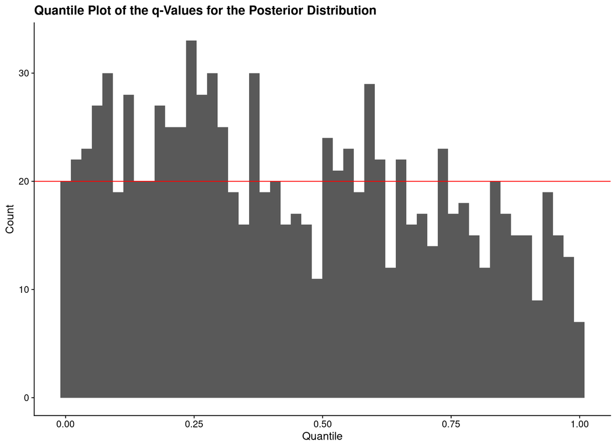

```r
plotvalid_tbl <- freqmodel_flat_validation_tbl %>%
  calculate_distribution_qvals(post_lambda, customer_lambda)

ggplot(plotvalid_tbl) +
  geom_histogram(aes(x = q_val), bins = 50) +
  geom_hline(aes(yintercept = plotvalid_tbl %>% nrow() %>% divide_by(50)), colour = "red") +
  labs(
    x = "Quantile",
    y = "Count",
    title = "Quantile Plot of the q-Values for the Posterior Distribution"
    )
```

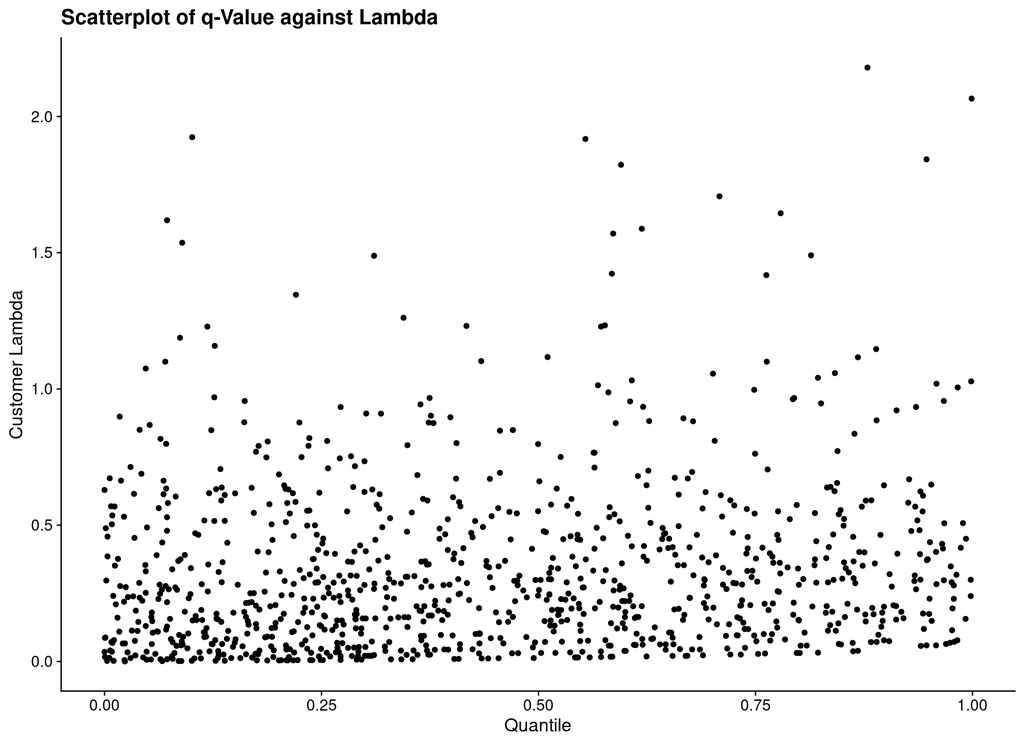

```r
ggplot(plotvalid_tbl) +
  geom_point(aes(x = q_val, y = customer_lambda)) +
  labs(
    x = "Quantile",
    y = "Customer Lambda",
    title = "Scatterplot of q-Value against Lambda"
    )
```

## 2.3 Fit Larger Model

We now repeat this model with a larger dataset.

```r
stan_data_lst <- fit_10000_data_tbl %>%
  select(customer_id, btyd_count, tnx_weeks = all_weeks) %>%
  compose_data()

freqmodel_flat_10k_stanfit <- freqmodel_flat_stanmodel$sample(
  data            =        stan_data_lst,
  chains          =                    4,
  iter_warmup     =                  500,
  iter_sampling   =                  500,
  seed            =                  422,
  output_dir      =        "stan_models",
  output_basename = "freqmodel_flat_10k"
  )
```

```
## Running MCMC with 4 parallel chains...
##
## Chain 1 Iteration:   1 / 1000 [  0%]  (Warmup)
## Chain 2 Iteration:   1 / 1000 [  0%]  (Warmup)
## Chain 3 Iteration:   1 / 1000 [  0%]  (Warmup)
## Chain 4 Iteration:   1 / 1000 [  0%]  (Warmup)
## Chain 1 Iteration: 100 / 1000 [ 10%]  (Warmup)
## Chain 2 Iteration: 100 / 1000 [ 10%]  (Warmup)
## Chain 4 Iteration: 100 / 1000 [ 10%]  (Warmup)
## Chain 3 Iteration: 100 / 1000 [ 10%]  (Warmup)
## Chain 1 Iteration: 200 / 1000 [ 20%]  (Warmup)
## Chain 2 Iteration: 200 / 1000 [ 20%]  (Warmup)
## Chain 4 Iteration: 200 / 1000 [ 20%]  (Warmup)
## Chain 3 Iteration: 200 / 1000 [ 20%]  (Warmup)
## Chain 1 Iteration: 300 / 1000 [ 30%]  (Warmup)
## Chain 2 Iteration: 300 / 1000 [ 30%]  (Warmup)
## Chain 4 Iteration: 300 / 1000 [ 30%]  (Warmup)
## Chain 3 Iteration: 300 / 1000 [ 30%]  (Warmup)
## Chain 1 Iteration: 400 / 1000 [ 40%]  (Warmup)
## Chain 2 Iteration: 400 / 1000 [ 40%]  (Warmup)
## Chain 4 Iteration: 400 / 1000 [ 40%]  (Warmup)
## Chain 3 Iteration: 400 / 1000 [ 40%]  (Warmup)
## Chain 1 Iteration: 500 / 1000 [ 50%]  (Warmup)
## Chain 1 Iteration: 501 / 1000 [ 50%]  (Sampling)
## Chain 2 Iteration: 500 / 1000 [ 50%]  (Warmup)
## Chain 2 Iteration: 501 / 1000 [ 50%]  (Sampling)
## Chain 4 Iteration: 500 / 1000 [ 50%]  (Warmup)
## Chain 4 Iteration: 501 / 1000 [ 50%]  (Sampling)
## Chain 3 Iteration: 500 / 1000 [ 50%]  (Warmup)
## Chain 3 Iteration: 501 / 1000 [ 50%]  (Sampling)
## Chain 1 Iteration: 600 / 1000 [ 60%]  (Sampling)
## Chain 2 Iteration: 600 / 1000 [ 60%]  (Sampling)
## Chain 4 Iteration: 600 / 1000 [ 60%]  (Sampling)
## Chain 3 Iteration: 600 / 1000 [ 60%]  (Sampling)
## Chain 1 Iteration: 700 / 1000 [ 70%]  (Sampling)
## Chain 2 Iteration: 700 / 1000 [ 70%]  (Sampling)
## Chain 4 Iteration: 700 / 1000 [ 70%]  (Sampling)
## Chain 3 Iteration: 700 / 1000 [ 70%]  (Sampling)
## Chain 1 Iteration: 800 / 1000 [ 80%]  (Sampling)
## Chain 2 Iteration: 800 / 1000 [ 80%]  (Sampling)
## Chain 4 Iteration: 800 / 1000 [ 80%]  (Sampling)
## Chain 3 Iteration: 800 / 1000 [ 80%]  (Sampling)
## Chain 1 Iteration: 900 / 1000 [ 90%]  (Sampling)
## Chain 2 Iteration: 900 / 1000 [ 90%]  (Sampling)
## Chain 4 Iteration: 900 / 1000 [ 90%]  (Sampling)
## Chain 3 Iteration: 900 / 1000 [ 90%]  (Sampling)
## Chain 1 Iteration: 1000 / 1000 [100%]  (Sampling)
## Chain 1 finished in 81.5 seconds.
## Chain 2 Iteration: 1000 / 1000 [100%]  (Sampling)
## Chain 2 finished in 83.1 seconds.
## Chain 4 Iteration: 1000 / 1000 [100%]  (Sampling)
## Chain 4 finished in 84.6 seconds.
## Chain 3 Iteration: 1000 / 1000 [100%]  (Sampling)
## Chain 3 finished in 85.4 seconds.
##
## All 4 chains finished successfully.
## Mean chain execution time: 83.7 seconds.
## Total execution time: 85.9 seconds.
```

```r
freqmodel_flat_10k_stanfit$summary()
```

```
## # A tibble: 10,001 × 10
##    variable       mean   median      sd     mad       q5      q95  rhat ess_bulk
##    <chr>         <dbl>    <dbl>   <dbl>   <dbl>    <dbl>    <dbl> <dbl>    <dbl>
##  1 lp__       -4.18e+4 -4.18e+4 72.6    74.6    -4.19e+4 -4.17e+4  1.00     671.
##  2 lambda[1]   5.52e-1  5.46e-1  0.0983  0.100   4.00e-1  7.24e-1  1.00    2373.
##  3 lambda[2]   3.06e-1  3.00e-1  0.0778  0.0779  1.94e-1  4.46e-1  1.01    2315.
##  4 lambda[3]   1.73e-1  1.68e-1  0.0589  0.0586  8.82e-2  2.79e-1  1.01    2635.
##  5 lambda[4]   8.27e-1  8.23e-1  0.129   0.128   6.28e-1  1.05e+0  1.00    2703.
##  6 lambda[5]   2.12e-1  2.05e-1  0.0669  0.0644  1.16e-1  3.36e-1  1.00    3278.
##  7 lambda[6]   7.76e-2  7.10e-2  0.0392  0.0356  2.61e-2  1.50e-1  1.00    2918.
##  8 lambda[7]   1.17e-1  1.11e-1  0.0473  0.0446  5.05e-2  2.06e-1  1.00    3021.
##  9 lambda[8]   7.73e-2  7.17e-2  0.0369  0.0351  2.65e-2  1.45e-1  1.01    3181.
## 10 lambda[9]   1.91e-2  1.34e-2  0.0186  0.0137  1.00e-3  5.61e-2  1.00    2163.
## # … with 9,991 more rows, and 1 more variable: ess_tail <dbl>
```

We first want to check the HMC diagnostics.

```r
freqmodel_flat_10k_stanfit$cmdstan_diagnose()
```

```
## Processing csv files: /home/rstudio/workshop/stan_models/freqmodel_flat_10k-1.csv, /home/rstudio/workshop/stan_models/freqmodel_flat_10k-2.csv, /home/rstudio/workshop/stan_models/freqmodel_flat_10k-3.csv, /home/rstudio/workshop/stan_models/freqmodel_flat_10k-4.csv
##
## Checking sampler transitions treedepth.
## Treedepth satisfactory for all transitions.
##
## Checking sampler transitions for divergences.
## No divergent transitions found.
##
## Checking E-BFMI - sampler transitions HMC potential energy.
## E-BFMI satisfactory.
##
## Effective sample size satisfactory.
##
## Split R-hat values satisfactory all parameters.
##
## Processing complete, no problems detected.
```

## 2.4 Check Larger Model Fit

We now repeat the validation exercise once more, extracting the posterior customer $\lambda$ values and comparing them to our input values.

```r
freqmodel_flat_10k_validation_tbl <- freqmodel_flat_10k_stanfit %>%
  recover_types(fit_10000_data_tbl) %>%
  spread_draws(lambda[customer_id]) %>%
  ungroup() %>%
  inner_join(customer_simparams_tbl, by = "customer_id") %>%
  select(customer_id, post_lambda = lambda, customer_lambda)

freqmodel_flat_10k_validation_tbl %>% glimpse()
```

```
## Rows: 20,000,000
## Columns: 3
## $ customer_id     <chr> "000JSNK3XH", "000JSNK3XH", "000JSNK3XH", "000JSNK3XH"…
## $ post_lambda     <dbl> 0.506860, 0.607616, 0.471304, 0.610821, 0.677388, 0.63…
## $ customer_lambda <dbl> 0.6374628, 0.6374628, 0.6374628, 0.6374628, 0.6374628,…
```

We also construct validation plots for this.

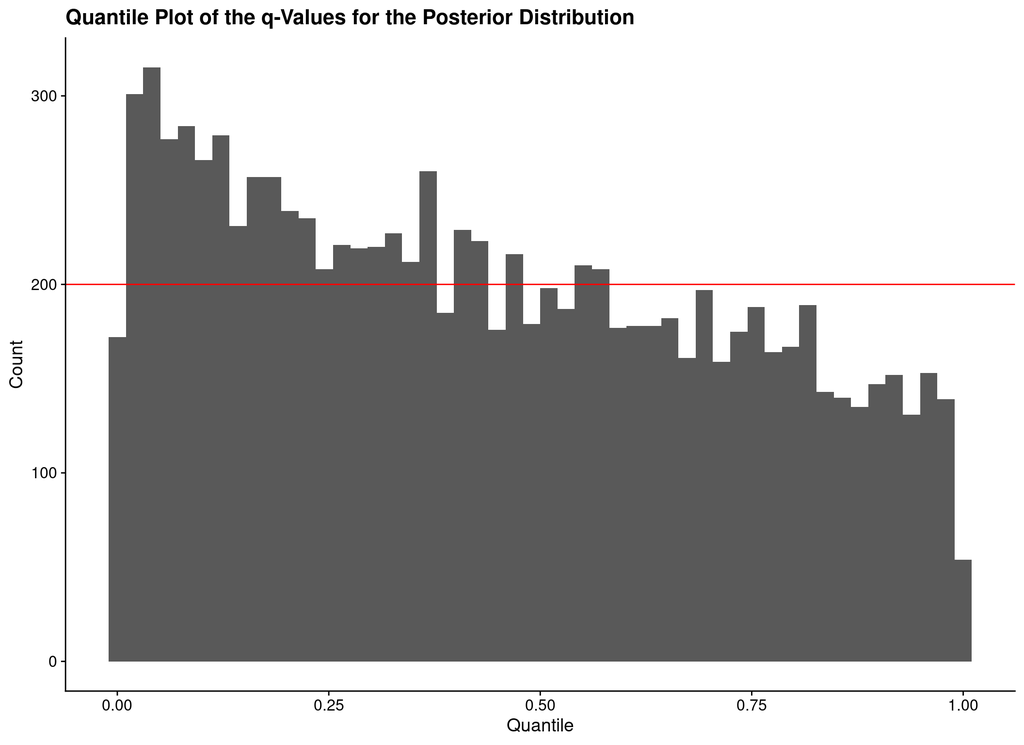

```r
plotvalid_tbl <- freqmodel_flat_10k_validation_tbl %>%
  calculate_distribution_qvals(post_lambda, customer_lambda)

ggplot(plotvalid_tbl) +
  geom_histogram(aes(x = q_val), bins = 50) +
  geom_hline(aes(yintercept = plotvalid_tbl %>% nrow() %>% divide_by(50)), colour = "red") +
  labs(
    x = "Quantile",
    y = "Count",
    title = "Quantile Plot of the q-Values for the Posterior Distribution"
    )
```

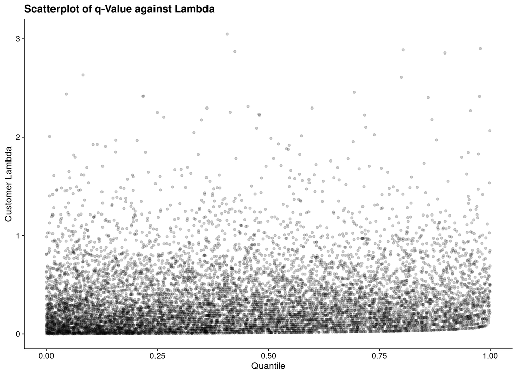

```r
ggplot(plotvalid_tbl) +
  geom_point(aes(x = q_val, y = customer_lambda), alpha = 0.2) +
  labs(
    x = "Quantile",
    y = "Customer Lambda",
    title = "Scatterplot of q-Value against Lambda"
    )
```

## 2.5 Construct Observed-Time Frequency Model

We now want to update our approach to use the observed duration of the transactions rather than using a constant time period of 52 weeks.

```r
stan_data_lst <- fit_1000_data_tbl %>%
  transmute(customer_id, btyd_count, tnx_weeks) %>%
  compose_data()

freqmodel_flat_obs_stanfit <- freqmodel_flat_stanmodel$sample(
  data            =        stan_data_lst,
  chains          =                    4,
  iter_warmup     =                  500,
  iter_sampling   =                  500,
  seed            =                  423,
  output_dir      =        "stan_models",
  output_basename = "freqmodel_flat_obs"
  )
```

```
## Running MCMC with 4 parallel chains...
##
## Chain 1 Iteration:   1 / 1000 [  0%]  (Warmup)
## Chain 2 Iteration:   1 / 1000 [  0%]  (Warmup)
## Chain 3 Iteration:   1 / 1000 [  0%]  (Warmup)
## Chain 4 Iteration:   1 / 1000 [  0%]  (Warmup)
## Chain 1 Iteration: 100 / 1000 [ 10%]  (Warmup)
## Chain 2 Iteration: 100 / 1000 [ 10%]  (Warmup)
## Chain 3 Iteration: 100 / 1000 [ 10%]  (Warmup)
## Chain 1 Iteration: 200 / 1000 [ 20%]  (Warmup)
## Chain 2 Iteration: 200 / 1000 [ 20%]  (Warmup)
## Chain 4 Iteration: 100 / 1000 [ 10%]  (Warmup)
## Chain 3 Iteration: 200 / 1000 [ 20%]  (Warmup)
## Chain 1 Iteration: 300 / 1000 [ 30%]  (Warmup)
## Chain 2 Iteration: 300 / 1000 [ 30%]  (Warmup)
## Chain 4 Iteration: 200 / 1000 [ 20%]  (Warmup)
## Chain 3 Iteration: 300 / 1000 [ 30%]  (Warmup)
## Chain 1 Iteration: 400 / 1000 [ 40%]  (Warmup)
## Chain 2 Iteration: 400 / 1000 [ 40%]  (Warmup)
## Chain 4 Iteration: 300 / 1000 [ 30%]  (Warmup)
## Chain 1 Iteration: 500 / 1000 [ 50%]  (Warmup)
## Chain 1 Iteration: 501 / 1000 [ 50%]  (Sampling)
## Chain 2 Iteration: 500 / 1000 [ 50%]  (Warmup)
## Chain 2 Iteration: 501 / 1000 [ 50%]  (Sampling)
## Chain 3 Iteration: 400 / 1000 [ 40%]  (Warmup)
## Chain 4 Iteration: 400 / 1000 [ 40%]  (Warmup)
## Chain 3 Iteration: 500 / 1000 [ 50%]  (Warmup)
## Chain 3 Iteration: 501 / 1000 [ 50%]  (Sampling)
## Chain 1 Iteration: 600 / 1000 [ 60%]  (Sampling)
## Chain 2 Iteration: 600 / 1000 [ 60%]  (Sampling)
## Chain 4 Iteration: 500 / 1000 [ 50%]  (Warmup)
## Chain 4 Iteration: 501 / 1000 [ 50%]  (Sampling)
## Chain 1 Iteration: 700 / 1000 [ 70%]  (Sampling)
## Chain 2 Iteration: 700 / 1000 [ 70%]  (Sampling)
## Chain 3 Iteration: 600 / 1000 [ 60%]  (Sampling)
## Chain 4 Iteration: 600 / 1000 [ 60%]  (Sampling)
## Chain 1 Iteration: 800 / 1000 [ 80%]  (Sampling)
## Chain 2 Iteration: 800 / 1000 [ 80%]  (Sampling)
## Chain 3 Iteration: 700 / 1000 [ 70%]  (Sampling)
## Chain 4 Iteration: 700 / 1000 [ 70%]  (Sampling)
## Chain 1 Iteration: 900 / 1000 [ 90%]  (Sampling)
## Chain 2 Iteration: 900 / 1000 [ 90%]  (Sampling)
## Chain 3 Iteration: 800 / 1000 [ 80%]  (Sampling)
## Chain 4 Iteration: 800 / 1000 [ 80%]  (Sampling)
## Chain 1 Iteration: 1000 / 1000 [100%]  (Sampling)
## Chain 2 Iteration: 1000 / 1000 [100%]  (Sampling)
## Chain 3 Iteration: 900 / 1000 [ 90%]  (Sampling)
## Chain 1 finished in 4.8 seconds.
## Chain 2 finished in 4.7 seconds.
## Chain 4 Iteration: 900 / 1000 [ 90%]  (Sampling)
## Chain 3 Iteration: 1000 / 1000 [100%]  (Sampling)
## Chain 3 finished in 4.8 seconds.
## Chain 4 Iteration: 1000 / 1000 [100%]  (Sampling)
## Chain 4 finished in 4.8 seconds.
##
## All 4 chains finished successfully.
## Mean chain execution time: 4.8 seconds.
## Total execution time: 5.4 seconds.
```

```r
freqmodel_flat_obs_stanfit$summary()
```

```
## # A tibble: 1,001 × 10
##    variable       mean   median      sd     mad       q5      q95  rhat ess_bulk
##    <chr>         <dbl>    <dbl>   <dbl>   <dbl>    <dbl>    <dbl> <dbl>    <dbl>
##  1 lp__       -4.02e+3 -4.02e+3 23.7    24.2    -4.06e+3 -3.98e+3  1.01     765.
##  2 lambda[1]   1.33e-1  1.23e-1  0.0653  0.0625  4.48e-2  2.49e-1  1.00    2451.
##  3 lambda[2]   2.88e-1  2.44e-1  0.205   0.182   4.88e-2  6.92e-1  1.00    1615.
##  4 lambda[3]   1.07e+0  1.06e+0  0.143   0.141   8.49e-1  1.31e+0  1.00    1945.
##  5 lambda[4]   3.68e-1  3.58e-1  0.0859  0.0837  2.40e-1  5.16e-1  1.00    2320.
##  6 lambda[5]   1.94e-2  1.39e-2  0.0191  0.0142  8.65e-4  5.64e-2  1.00    1884.
##  7 lambda[6]   8.70e-2  8.04e-2  0.0428  0.0386  2.88e-2  1.65e-1  1.00    1907.
##  8 lambda[7]   5.38e-1  5.33e-1  0.100   0.0980  3.80e-1  7.11e-1  1.00    2244.
##  9 lambda[8]   3.14e-1  3.04e-1  0.0780  0.0741  2.00e-1  4.57e-1  1.00    2475.
## 10 lambda[9]   4.93e-1  4.89e-1  0.0983  0.0965  3.41e-1  6.67e-1  1.00    2707.
## # … with 991 more rows, and 1 more variable: ess_tail <dbl>
```

Now that we have fit our models, we repeat our validation model much like we did the last time. We expect this model to deviate from our first model however as we have a less-reliable estimate of the observation time for each customer - as it is now calculated as ending at the last observation.

```r
freqmodel_flat_obs_validation_tbl <- freqmodel_flat_obs_stanfit %>%
  recover_types(fit_1000_data_tbl) %>%
  spread_draws(lambda[customer_id]) %>%
  ungroup() %>%
  inner_join(customer_simparams_tbl, by = "customer_id") %>%
  select(customer_id, post_lambda = lambda, customer_lambda)

freqmodel_flat_obs_validation_tbl %>% glimpse()
```

```
## Rows: 2,000,000
## Columns: 3
## $ customer_id     <chr> "00RC3IE4XG", "00RC3IE4XG", "00RC3IE4XG", "00RC3IE4XG"…
## $ post_lambda     <dbl> 0.1511800, 0.0799502, 0.2983930, 0.0345082, 0.0995931,…
## $ customer_lambda <dbl> 0.05118089, 0.05118089, 0.05118089, 0.05118089, 0.0511…
```

We also construct validation plots for this.

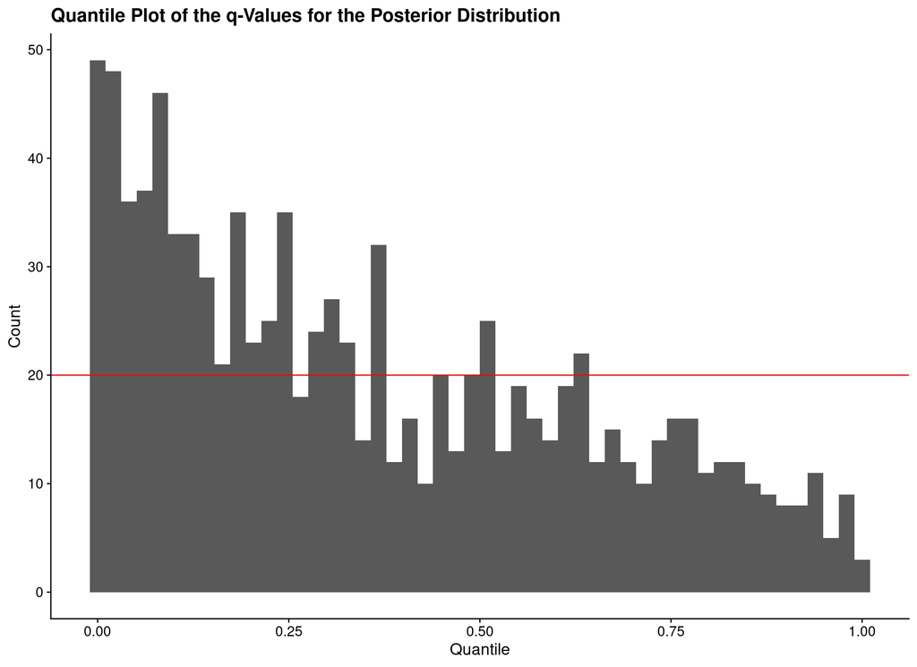

```r
plotvalid_tbl <- freqmodel_flat_obs_validation_tbl %>%
  calculate_distribution_qvals(post_lambda, customer_lambda)

ggplot(plotvalid_tbl) +
  geom_histogram(aes(x = q_val), bins = 50) +
  geom_hline(aes(yintercept = plotvalid_tbl %>% nrow() %>% divide_by(50)), colour = "red") +
  labs(
    x = "Quantile",
    y = "Count",
    title = "Quantile Plot of the q-Values for the Posterior Distribution"
    )
```

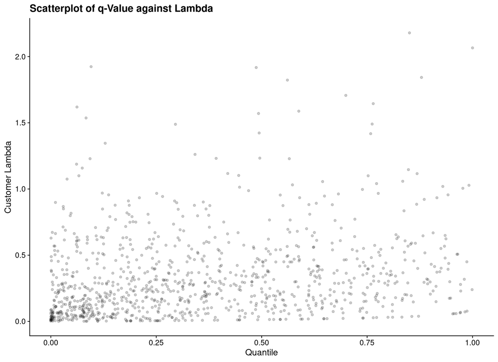

```r
ggplot(plotvalid_tbl) +
  geom_point(aes(x = q_val, y = customer_lambda), alpha = 0.2) +
  labs(
    x = "Quantile",
    y = "Customer Lambda",
    title = "Scatterplot of q-Value against Lambda"
    )
```

## 2.6 Construct Posterior Distribution Comparisons

We now combine the outputted posterior distributions and compare them together.

```r
comparison_distrib_tbl <- list(
    `Fixed Time`    = freqmodel_flat_validation_tbl,
    `Observed Time` = freqmodel_flat_obs_validation_tbl
    ) %>%
  bind_rows(.id = "label")

comparison_distrib_tbl %>% glimpse()
```

```
## Rows: 4,000,000
## Columns: 4
## $ label           <chr> "Fixed Time", "Fixed Time", "Fixed Time", "Fixed Time"…
## $ customer_id     <chr> "00RC3IE4XG", "00RC3IE4XG", "00RC3IE4XG", "00RC3IE4XG"…
## $ post_lambda     <dbl> 0.0737775, 0.0760951, 0.0786928, 0.0757330, 0.1026330,…
## $ customer_lambda <dbl> 0.05118089, 0.05118089, 0.05118089, 0.05118089, 0.0511…
```

Now that we have this data we can construct a number of visualisations to help us compare these two distributions on a per-customer basis.

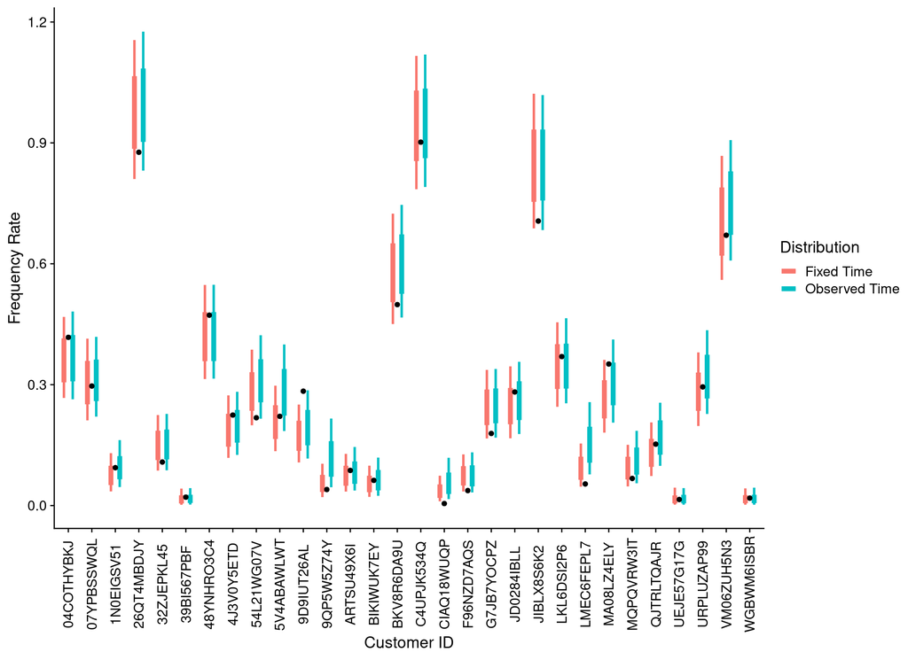

```r
comparison_summary_tbl <- comparison_distrib_tbl %>%
  group_by(label, customer_id) %>%
  summarise(
    .groups = "drop",

    labels = c("q10", "q25", "q50", "q75", "q90", "mean", "customer_lambda"),
    vals   = c(quantile(post_lambda, probs = c(0.1, 0.25, 0.50, 0.75, 0.90)),
               mean(post_lambda),
               unique(customer_lambda))
    ) %>%
  pivot_wider(
    names_from  = labels,
    values_from = vals
    )

plot_tbl <- comparison_summary_tbl %>%
  group_nest(customer_id) %>%
  slice_sample(n = 30) %>%
  unnest(data)

ggplot(plot_tbl) +
  geom_errorbar(
    aes(x = customer_id, ymin = q10, ymax = q90, colour = label),
    position = position_dodge(width = 0.75), width = 0, size = 1) +
  geom_errorbar(
    aes(x = customer_id, ymin = q25, ymax = q75, colour = label),
    position = position_dodge(width = 0.75), width = 0, size = 2) +
  geom_point(aes(x = customer_id, y = customer_lambda)) +
  labs(
    x = "Customer ID",
    y = "Frequency Rate",
    colour = "Distribution"
    ) +
  theme(axis.text.x = element_text(angle = 90, vjust = 0.5))
```

As there is a broad selection of different `lambda` values, we draw a random selection of `customer_id` for different ranges of these values.

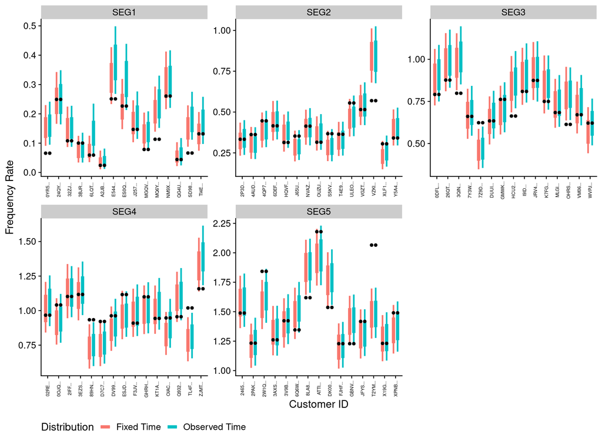

```r
plotdata_tbl <- comparison_summary_tbl %>%
  mutate(
    lambda_segment = case_when(
      (customer_lambda > 0.00 & customer_lambda <= 0.30) ~ "SEG1",
      (customer_lambda > 0.30 & customer_lambda <= 0.60) ~ "SEG2",
      (customer_lambda > 0.60 & customer_lambda <= 0.90) ~ "SEG3",
      (customer_lambda > 0.90 & customer_lambda <= 1.20) ~ "SEG4",
      (customer_lambda > 1.20)                           ~ "SEG5",
      TRUE ~ "ERROR"
      )
    ) %>%
  group_nest(lambda_segment) %>%
  mutate(
    sample_data = map(data, ~ .x %>% group_nest(customer_id) %>% slice_sample(n = 15))
    ) %>%
  select(lambda_segment, sample_data) %>%
  unnest(sample_data) %>%
  unnest(data)


ggplot(plotdata_tbl %>% mutate(customer_id = str_trunc(customer_id, width = 7))) +
  geom_errorbar(
    aes(x = customer_id, ymin = q10, ymax = q90, colour = label),
    position = position_dodge(width = 0.75), width = 0, size = 1) +
  geom_errorbar(
    aes(x = customer_id, ymin = q25, ymax = q75, colour = label),
    position = position_dodge(width = 0.75), width = 0, size = 2) +
  geom_point(
    aes(x = customer_id, y = customer_lambda, group = label),
    position = position_dodge(width = 0.75)) +
  facet_wrap(vars(lambda_segment), scales = "free") +
  labs(
    x = "Customer ID",
    y = "Frequency Rate",
    colour = "Distribution"
    ) +
  theme(
    axis.text.x = element_text(angle = 90, vjust = 0.5, size = 6),
    legend.position = "bottom"
    )
```

## 2.7 Estimate Posterior Interval Coverage

One final validity check is to see how often the ‘true’ `lambda` value falls within our posterior intervals. We create a boolean variable for both intervals (the 50% and the 80%) and then check the proportion of values against the width.

```r
coverage_stats_tbl <- comparison_summary_tbl %>%
  mutate(
    up_50 = customer_lambda > q75,
    dn_50 = customer_lambda < q25,
    up_80 = customer_lambda < q10,
    dn_80 = customer_lambda > q90,
    cover_50 = (!up_50 & !dn_50),
    cover_80 = (!up_80 & !dn_80)
    )

coverage_stats_tbl %>%
  group_by(label) %>%
  summarise(
    .groups = "drop",

    prop_50 = sum(cover_50) / n(),
    prop_80 = sum(cover_80) / n(),

    prop_up50 = sum(up_50) / n(),
    prop_dn50 = sum(dn_50) / n(),
    prop_up80 = sum(up_80) / n(),
    prop_dn80 = sum(dn_80) / n()
    )
```

```
## # A tibble: 2 × 7
##   label         prop_50 prop_80 prop_up50 prop_dn50 prop_up80 prop_dn80
##   <chr>           <dbl>   <dbl>     <dbl>     <dbl>     <dbl>     <dbl>
## 1 Fixed Time      0.503   0.805     0.186     0.311     0.129     0.066
## 2 Observed Time   0.438   0.73      0.125     0.437     0.23      0.04
```

These numbers line up with what we expect, though we can see that using the observed time as our input introduces an upward bias in inferred values for `lambda`. We could assess further using bootstrap techniques, but I do not think it is necessary.

We will leave repeating the above analysis for the larger datasets as an exercise.

# 3 Adding Priors to the Model

We now want to add priors to our model to improve our inferences. Our current model provides no input for our prior knowledge on the values of `lambda` - but a bit of thought will show this is not correct. For example, we know that a value above 10.0 is almost impossible, and most customers will have a `lambda` rate between 0 and 1 say, averaging around roughly 0.25.

A good choice for this distribution is the Gamma with a shape parameter of 1 and a ‘rate’ parameter of 4.

We can check what this looks like by simulation:

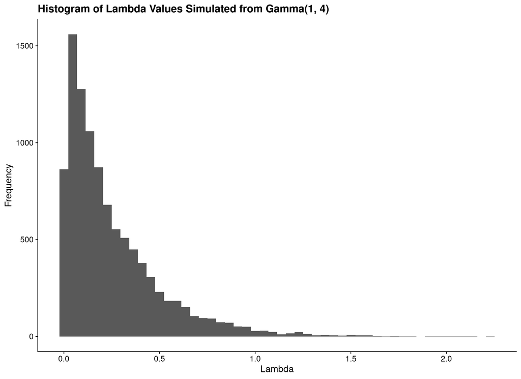

```r
lambda_vals <- rgamma(10000, shape = 1, rate = 4)

ggplot() +
  geom_histogram(aes(x = lambda_vals), bins = 50) +
  labs(
    x = "Lambda",
    y = "Frequency",
    title = "Histogram of Lambda Values Simulated from Gamma(1, 4)"
    )
```

The above distribution looks reasonable, though perhaps we would want a bit more probability mass at the higher end.

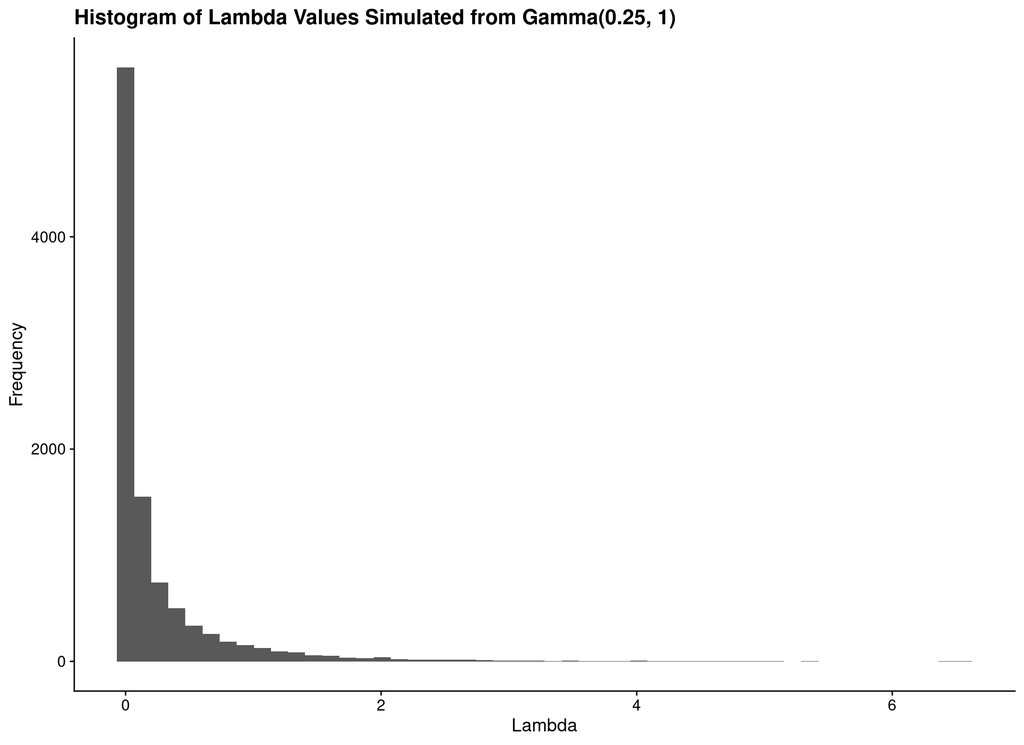

```r
lambda_vals <- rgamma(10000, shape = 0.25, rate = 1.0)

ggplot() +
  geom_histogram(aes(x = lambda_vals), bins = 50) +
  labs(
    x = "Lambda",
    y = "Frequency",
    title = "Histogram of Lambda Values Simulated from Gamma(0.25, 1)"
    )
```

This distribution looks a lot more skewed, so we also plot this histogram on a log-scale.

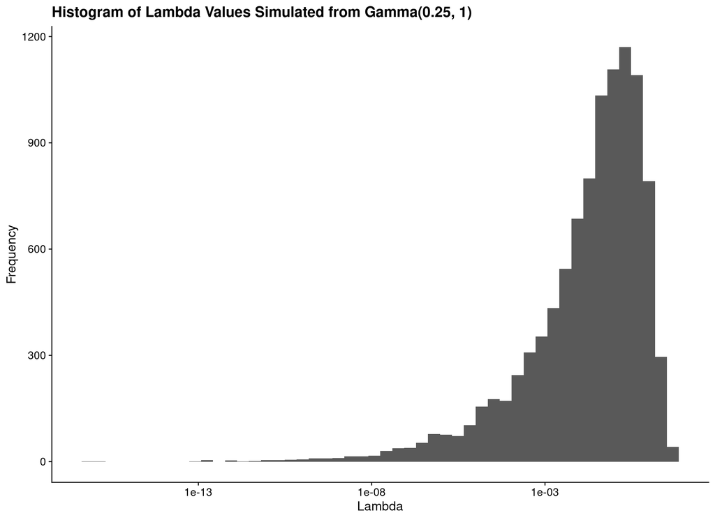

```r
ggplot() +
  geom_histogram(aes(x = lambda_vals), bins = 50) +
  scale_x_log10() +
  labs(
    x = "Lambda",
    y = "Frequency",
    title = "Histogram of Lambda Values Simulated from Gamma(0.25, 1)"
    )
```

## 3.1 Construct Stan Model with Priors on Lambda

This is ‘prior’ knowledge and we can set up these priors for the parameters within our model to allow for this prior knowledge.

```
## data {
##   int<lower=1> n;               // count of observations
##
##   int<lower=0> btyd_count[n];   // observed number of transactions
##   vector<lower=0>[n] tnx_weeks; // observed time-period of transactions
##
##   real r;
##   real alpha;
## }
##
## parameters {
##   vector<lower=0>[n] lambda;
## }
##
## model {
##   lambda ~ gamma(r, alpha);
##
##   target += poisson_lpmf(btyd_count | lambda .* tnx_weeks);
## }
```

You can see we have now added code to say that our posterior inference on each customer value for `lambda` is the combination of a prior Gamma distribution and our Poisson likelihood for the observed counts.

We now compile this model using `CmdStanR`.

```r
freqmodel_prior_stanmodel <- cmdstan_model(
  "stan_code/freqmodel_prior.stan",
  include_paths = "stan_code/",
  pedantic      =  TRUE,
  dir           = "stan_models/"
  )
```

Having compiled the Stan model, we now fit it with our data.

```r
stan_data_lst <- fit_1000_data_tbl %>%
  transmute(customer_id, btyd_count, tnx_weeks) %>%
  compose_data(
    r     =  0.25,
    alpha =     1
    )

freqmodel_prior_stanfit <- freqmodel_prior_stanmodel$sample(
  data            =        stan_data_lst,
  chains          =                    4,
  iter_warmup     =                  500,
  iter_sampling   =                  500,
  seed            =                  424,
  output_dir      =        "stan_models",
  output_basename =    "freqmodel_prior"
  )
```

```
## Running MCMC with 4 parallel chains...
##
## Chain 1 Iteration:   1 / 1000 [  0%]  (Warmup)
## Chain 2 Iteration:   1 / 1000 [  0%]  (Warmup)
## Chain 3 Iteration:   1 / 1000 [  0%]  (Warmup)
## Chain 4 Iteration:   1 / 1000 [  0%]  (Warmup)
## Chain 1 Iteration: 100 / 1000 [ 10%]  (Warmup)
## Chain 2 Iteration: 100 / 1000 [ 10%]  (Warmup)
## Chain 4 Iteration: 100 / 1000 [ 10%]  (Warmup)
## Chain 3 Iteration: 100 / 1000 [ 10%]  (Warmup)
## Chain 1 Iteration: 200 / 1000 [ 20%]  (Warmup)
## Chain 2 Iteration: 200 / 1000 [ 20%]  (Warmup)
## Chain 4 Iteration: 200 / 1000 [ 20%]  (Warmup)
## Chain 3 Iteration: 200 / 1000 [ 20%]  (Warmup)
## Chain 2 Iteration: 300 / 1000 [ 30%]  (Warmup)
## Chain 1 Iteration: 300 / 1000 [ 30%]  (Warmup)
## Chain 3 Iteration: 300 / 1000 [ 30%]  (Warmup)
## Chain 4 Iteration: 300 / 1000 [ 30%]  (Warmup)
## Chain 2 Iteration: 400 / 1000 [ 40%]  (Warmup)
## Chain 1 Iteration: 400 / 1000 [ 40%]  (Warmup)
## Chain 3 Iteration: 400 / 1000 [ 40%]  (Warmup)
## Chain 4 Iteration: 400 / 1000 [ 40%]  (Warmup)
## Chain 2 Iteration: 500 / 1000 [ 50%]  (Warmup)
## Chain 2 Iteration: 501 / 1000 [ 50%]  (Sampling)
## Chain 1 Iteration: 500 / 1000 [ 50%]  (Warmup)
## Chain 1 Iteration: 501 / 1000 [ 50%]  (Sampling)
## Chain 3 Iteration: 500 / 1000 [ 50%]  (Warmup)
## Chain 3 Iteration: 501 / 1000 [ 50%]  (Sampling)
## Chain 4 Iteration: 500 / 1000 [ 50%]  (Warmup)
## Chain 4 Iteration: 501 / 1000 [ 50%]  (Sampling)
## Chain 2 Iteration: 600 / 1000 [ 60%]  (Sampling)
## Chain 1 Iteration: 600 / 1000 [ 60%]  (Sampling)
## Chain 3 Iteration: 600 / 1000 [ 60%]  (Sampling)
## Chain 4 Iteration: 600 / 1000 [ 60%]  (Sampling)
## Chain 2 Iteration: 700 / 1000 [ 70%]  (Sampling)
## Chain 1 Iteration: 700 / 1000 [ 70%]  (Sampling)
## Chain 3 Iteration: 700 / 1000 [ 70%]  (Sampling)
## Chain 4 Iteration: 700 / 1000 [ 70%]  (Sampling)
## Chain 2 Iteration: 800 / 1000 [ 80%]  (Sampling)
## Chain 1 Iteration: 800 / 1000 [ 80%]  (Sampling)
## Chain 3 Iteration: 800 / 1000 [ 80%]  (Sampling)
## Chain 4 Iteration: 800 / 1000 [ 80%]  (Sampling)
## Chain 2 Iteration: 900 / 1000 [ 90%]  (Sampling)
## Chain 1 Iteration: 900 / 1000 [ 90%]  (Sampling)
## Chain 3 Iteration: 900 / 1000 [ 90%]  (Sampling)
## Chain 4 Iteration: 900 / 1000 [ 90%]  (Sampling)
## Chain 2 Iteration: 1000 / 1000 [100%]  (Sampling)
## Chain 2 finished in 12.1 seconds.
## Chain 1 Iteration: 1000 / 1000 [100%]  (Sampling)
## Chain 3 Iteration: 1000 / 1000 [100%]  (Sampling)
## Chain 4 Iteration: 1000 / 1000 [100%]  (Sampling)
## Chain 1 finished in 12.5 seconds.
## Chain 3 finished in 12.2 seconds.
## Chain 4 finished in 12.0 seconds.
##
## All 4 chains finished successfully.
## Mean chain execution time: 12.2 seconds.
## Total execution time: 12.6 seconds.
```

```r
freqmodel_prior_stanfit$summary()
```

```
## # A tibble: 1,001 × 10
##    variable       mean   median      sd     mad       q5      q95  rhat ess_bulk
##    <chr>         <dbl>    <dbl>   <dbl>   <dbl>    <dbl>    <dbl> <dbl>    <dbl>
##  1 lp__       -3.31e+3 -3.31e+3 2.22e+1 2.23e+1 -3.35e+3 -3.27e+3 1.00      858.
##  2 lambda[1]   1.05e-1  9.41e-2 5.73e-2 5.28e-2  3.22e-2  2.15e-1 1.00     1950.
##  3 lambda[2]   1.64e-1  1.19e-1 1.49e-1 1.13e-1  1.39e-2  4.58e-1 1.00     1724.
##  4 lambda[3]   1.03e+0  1.02e+0 1.46e-1 1.39e-1  7.99e-1  1.28e+0 1.00     2589.
##  5 lambda[4]   3.48e-1  3.44e-1 8.13e-2 8.47e-2  2.27e-1  4.96e-1 1.00     2316.
##  6 lambda[5]   4.83e-3  9.67e-4 9.85e-3 1.43e-3  8.73e-8  2.33e-2 1.00      978.
##  7 lambda[6]   7.07e-2  6.29e-2 3.86e-2 3.31e-2  2.12e-2  1.44e-1 0.999    2089.
##  8 lambda[7]   5.13e-1  5.06e-1 9.97e-2 9.85e-2  3.59e-1  6.86e-1 1.00     2407.
##  9 lambda[8]   2.93e-1  2.84e-1 7.53e-2 7.31e-2  1.83e-1  4.28e-1 1.00     2552.
## 10 lambda[9]   4.69e-1  4.62e-1 9.86e-2 9.42e-2  3.22e-1  6.44e-1 1.00     2927.
## # … with 991 more rows, and 1 more variable: ess_tail <dbl>
```

Once again, we want to check the HMC diagnostics.

```r
freqmodel_prior_stanfit$cmdstan_diagnose()
```

```
## Processing csv files: /home/rstudio/workshop/stan_models/freqmodel_prior-1.csv, /home/rstudio/workshop/stan_models/freqmodel_prior-2.csv, /home/rstudio/workshop/stan_models/freqmodel_prior-3.csv, /home/rstudio/workshop/stan_models/freqmodel_prior-4.csv
##
## Checking sampler transitions treedepth.
## Treedepth satisfactory for all transitions.
##
## Checking sampler transitions for divergences.
## No divergent transitions found.
##
## Checking E-BFMI - sampler transitions HMC potential energy.
## E-BFMI satisfactory.
##
## Effective sample size satisfactory.
##
## Split R-hat values satisfactory all parameters.
##
## Processing complete, no problems detected.
```

## 3.2 Check Posterior Lambda Values

We repeat our validation exercise from before, comparing the outputs of the posterior distribution for each `lambda` against the known true value.

```r
freqmodel_prior_validation_tbl <- freqmodel_prior_stanfit %>%
  recover_types(fit_1000_data_tbl) %>%
  spread_draws(lambda[customer_id]) %>%
  ungroup() %>%
  inner_join(customer_simparams_tbl, by = "customer_id") %>%
  select(customer_id, post_lambda = lambda, customer_lambda)

freqmodel_prior_validation_tbl %>% glimpse()
```

```
## Rows: 2,000,000
## Columns: 3
## $ customer_id     <chr> "00RC3IE4XG", "00RC3IE4XG", "00RC3IE4XG", "00RC3IE4XG"…
## $ post_lambda     <dbl> 0.0994220, 0.1445900, 0.0530588, 0.0488157, 0.0837054,…
## $ customer_lambda <dbl> 0.05118089, 0.05118089, 0.05118089, 0.05118089, 0.0511…
```

We now calculate the q-values of each parameter against the posterior distribution and plot a histogram of these q-values.

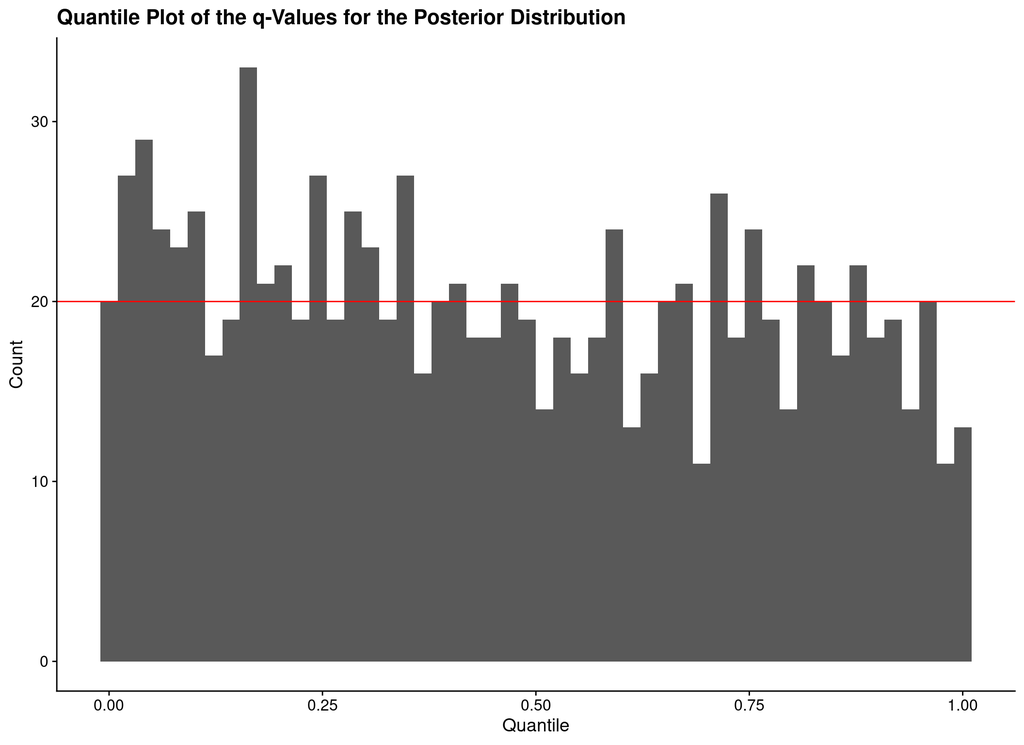

```r
plotvalid_tbl <- freqmodel_prior_validation_tbl %>%
  calculate_distribution_qvals(post_lambda, customer_lambda)

ggplot(plotvalid_tbl) +
  geom_histogram(aes(x = q_val), bins = 50) +
  geom_hline(aes(yintercept = plotvalid_tbl %>% nrow() %>% divide_by(50)), colour = "red") +
  labs(
    x = "Quantile",
    y = "Count",
    title = "Quantile Plot of the q-Values for the Posterior Distribution"
    )
```

## 3.3 Comparing the Uniform Prior and Gamma Prior Posteriors

Now we have both posterior distributions based on the observed lifetime of the customer and it is useful to compare the two distributions.

```r
comparison_distrib_tbl <- list(
    `Flat`  = freqmodel_flat_obs_validation_tbl,
    `Prior` = freqmodel_prior_validation_tbl
    ) %>%
  bind_rows(.id = "label")

comparison_distrib_tbl %>% glimpse()
```

```
## Rows: 4,000,000
## Columns: 4
## $ label           <chr> "Flat", "Flat", "Flat", "Flat", "Flat", "Flat", "Flat"…
## $ customer_id     <chr> "00RC3IE4XG", "00RC3IE4XG", "00RC3IE4XG", "00RC3IE4XG"…
## $ post_lambda     <dbl> 0.1511800, 0.0799502, 0.2983930, 0.0345082, 0.0995931,…
## $ customer_lambda <dbl> 0.05118089, 0.05118089, 0.05118089, 0.05118089, 0.0511…
```

We now can compare the outputs of the two posterior distributions based on using a uniform prior and Gamma prior.

```r
comparison_summary_tbl <- comparison_distrib_tbl %>%
  group_by(label, customer_id) %>%
  summarise(
    .groups = "drop",

    labels = c("q10", "q25", "q50", "q75", "q90", "mean", "customer_lambda"),
    vals   = c(quantile(post_lambda, probs = c(0.1, 0.25, 0.50, 0.75, 0.90)),
               mean(post_lambda),
               unique(customer_lambda))
    ) %>%
  pivot_wider(
    names_from  = labels,
    values_from = vals
    )

comparison_summary_tbl %>% glimpse()
```

```
## Rows: 2,000
## Columns: 9
## $ label           <chr> "Flat", "Flat", "Flat", "Flat", "Flat", "Flat", "Flat"…
## $ customer_id     <chr> "00RC3IE4XG", "02NO5FZ0VS", "02RE0JNCFQ", "04COTHYBKJ"…
## $ q10             <dbl> 0.057849420, 0.074813270, 0.887696300, 0.263768600, 0.…
## $ q25             <dbl> 0.086321350, 0.133528250, 0.966570750, 0.308264000, 0.…
## $ q50             <dbl> 0.12289250, 0.24385750, 1.05678000, 0.35788950, 0.0138…
## $ q75             <dbl> 0.17175900, 0.38584100, 1.15885000, 0.42331550, 0.0270…
## $ q90             <dbl> 0.21766680, 0.56551450, 1.25484200, 0.48155410, 0.0439…
## $ mean            <dbl> 0.13285014, 0.28844774, 1.06707382, 0.36753896, 0.0193…
## $ customer_lambda <dbl> 0.051180893, 0.042939056, 0.966878916, 0.417482035, 0.…
```

Now that we have summary stats of the two distributions we segment our data into the different groups of known values for `lambda` and then plot the range of values for the different distributions.

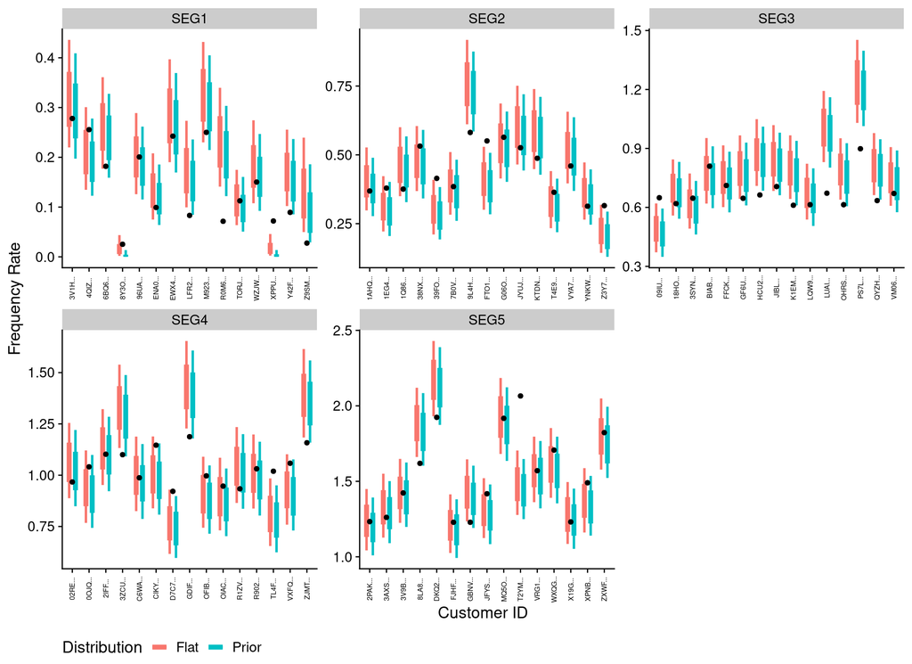

```r
plotdata_tbl <- comparison_summary_tbl %>%
  mutate(
    lambda_segment = case_when(
      (customer_lambda > 0.00 & customer_lambda <= 0.30) ~ "SEG1",
      (customer_lambda > 0.30 & customer_lambda <= 0.60) ~ "SEG2",
      (customer_lambda > 0.60 & customer_lambda <= 0.90) ~ "SEG3",
      (customer_lambda > 0.90 & customer_lambda <= 1.20) ~ "SEG4",
      (customer_lambda > 1.20)                           ~ "SEG5",
      TRUE ~ "ERROR"
      )
    ) %>%
  group_nest(lambda_segment) %>%
  mutate(
    sample_data = map(data, ~ .x %>% group_nest(customer_id) %>% slice_sample(n = 15))
    ) %>%
  select(lambda_segment, sample_data) %>%
  unnest(sample_data) %>%
  unnest(data)


ggplot(plotdata_tbl %>% mutate(customer_id = str_trunc(customer_id, width = 7))) +
  geom_errorbar(
    aes(x = customer_id, ymin = q10, ymax = q90, colour = label),
    position = position_dodge(width = 0.75), width = 0, size = 1) +
  geom_errorbar(
    aes(x = customer_id, ymin = q25, ymax = q75, colour = label),
    position = position_dodge(width = 0.75), width = 0, size = 2) +
  geom_point(
    aes(x = customer_id, y = customer_lambda)) +
  facet_wrap(vars(lambda_segment), scales = "free") +
  labs(
    x = "Customer ID",
    y = "Frequency Rate",
    colour = "Distribution"
    ) +
  theme(
    axis.text.x = element_text(angle = 90, vjust = 0.5, size = 6),
    legend.position = "bottom"
    )
```

And we also want to compare the two distributions for the posterior coverage.

```r
coverage_stats_tbl <- comparison_summary_tbl %>%
  mutate(
    up_50 = customer_lambda > q75,
    dn_50 = customer_lambda < q25,
    up_80 = customer_lambda < q10,
    dn_80 = customer_lambda > q90,
    cover_50 = (!up_50 & !dn_50),
    cover_80 = (!up_80 & !dn_80)
    )

coverage_stats_tbl %>%
  group_by(label) %>%
  summarise(
    .groups = "drop",

    prop_50 = sum(cover_50) / n(),
    prop_80 = sum(cover_80) / n(),

    prop_up50 = sum(up_50) / n(),
    prop_dn50 = sum(dn_50) / n(),
    prop_up80 = sum(up_80) / n(),
    prop_dn80 = sum(dn_80) / n()
    )
```

```
## # A tibble: 2 × 7
##   label prop_50 prop_80 prop_up50 prop_dn50 prop_up80 prop_dn80
##   <chr>   <dbl>   <dbl>     <dbl>     <dbl>     <dbl>     <dbl>
## 1 Flat    0.438   0.73      0.125     0.437     0.23      0.04
## 2 Prior   0.474   0.779     0.229     0.297     0.137     0.084
```

[output not shown]

# 4 R Environment

```r
options(width = 120L)
```

```r
options(width = 80L)
```